# IODS course project

Ville Aro

23/11/2019

# Excercise 1

## About the project

**How are you feeling right now?**

*Feeling well, maybe a bit tired as it is already sunday evening. Just finished the datacamp trainings which were actually quite fun.*

**What do you expect to learn?**

*Expect to learn the basics of r, and to be able to use r more independently in the future instead of SPSS. Basic understanding of coding, its possibilities and utilities for work/personal life.*

**Where did you hear about the course?**

*My Brother messaged me about this course and said it could be useful and interesting. I work full time and I’m also doing my thesis. To this point I have been using SPSS, but maybe I can try some analysis with r aswell for the data.*

LINK: https://github.com/Ville-Aro/IODS-project

# Exercise 2

```r
install.packages("dplyr", repos="http://cran.us.r-project.org")
```

```r
install.packages("ggplot2", repos="http://cran.us.r-project.org")
install.packages("GGally", repos="http://cran.us.r-project.org")
library(ggplot2)
library(GGally)
library(dplyr)
```

## 1 Reading the data

```r
harjoitusdata <- read.table("data/Create_learning2014", header=TRUE)
summary(harjoitusdata$Age)
```

```
##    Min. 1st Qu.  Median    Mean 3rd Qu.    Max.
##   17.00   21.00   22.00   25.51   27.00   55.00
```

```r
str(harjoitusdata)
```

```
## 'data.frame':    166 obs. of  7 variables:
##  $ gender  : Factor w/ 2 levels "F","M": 1 2 1 2 2 1 2 1 2 1 ...
##  $ Age     : int  53 55 49 53 49 38 50 37 37 42 ...
##  $ Attitude: num  3.7 3.1 2.5 3.5 3.7 3.8 3.5 2.9 3.8 2.1 ...
##  $ deep    : num  3.58 2.92 3.5 3.5 3.67 ...
##  $ stra    : num  3.38 2.75 3.62 3.12 3.62 ...
##  $ surf    : num  2.58 3.17 2.25 2.25 2.83 ...
##  $ Points  : int  25 12 24 10 22 21 21 31 24 26 ...
```

## 1a Describing the data

The dataset has been collected during 12/2014-1/2015. The data consists of 166 observations and has 7 variables, which are

**1)** Gender= Subjects gender, male / female **2)** Age = Subjects age ranging from 17 to 55, with the mean being 25,51 **3)** Attitude, which measures global attitude toward statistics with 10 questions. The attitude variable is a meansum variable of these 10 questions. **4)** Deep is a factor variable that measures the deep learning, it is also a meansum variable consisting of 12 questions **5)** Stra factor variable measures Stategic learning cababilities, it consist of 8 questions and is a meansum variable of these. **6)** surf is a factor variable measures the surface learning cababilities via 12 questions. **7)** Points variable measures how many points in total an individual received from the course exam

## 2 Graphical overview of the data

```r
summary(harjoitusdata)
```

```
##  gender       Age           Attitude          deep            stra
##  F:110   Min.   :17.00   Min.   :1.400   Min.   :1.583   Min.   :1.250
##  M: 56   1st Qu.:21.00   1st Qu.:2.600   1st Qu.:3.333   1st Qu.:2.625
##          Median :22.00   Median :3.200   Median :3.667   Median :3.188
##          Mean   :25.51   Mean   :3.143   Mean   :3.680   Mean   :3.121
##          3rd Qu.:27.00   3rd Qu.:3.700   3rd Qu.:4.083   3rd Qu.:3.625
##          Max.   :55.00   Max.   :5.000   Max.   :4.917   Max.   :5.000
##       surf           Points
##  Min.   :1.583   Min.   : 7.00
##  1st Qu.:2.417   1st Qu.:19.00
##  Median :2.833   Median :23.00
##  Mean   :2.787   Mean   :22.72
##  3rd Qu.:3.167   3rd Qu.:27.75
##  Max.   :4.333   Max.   :33.00
```

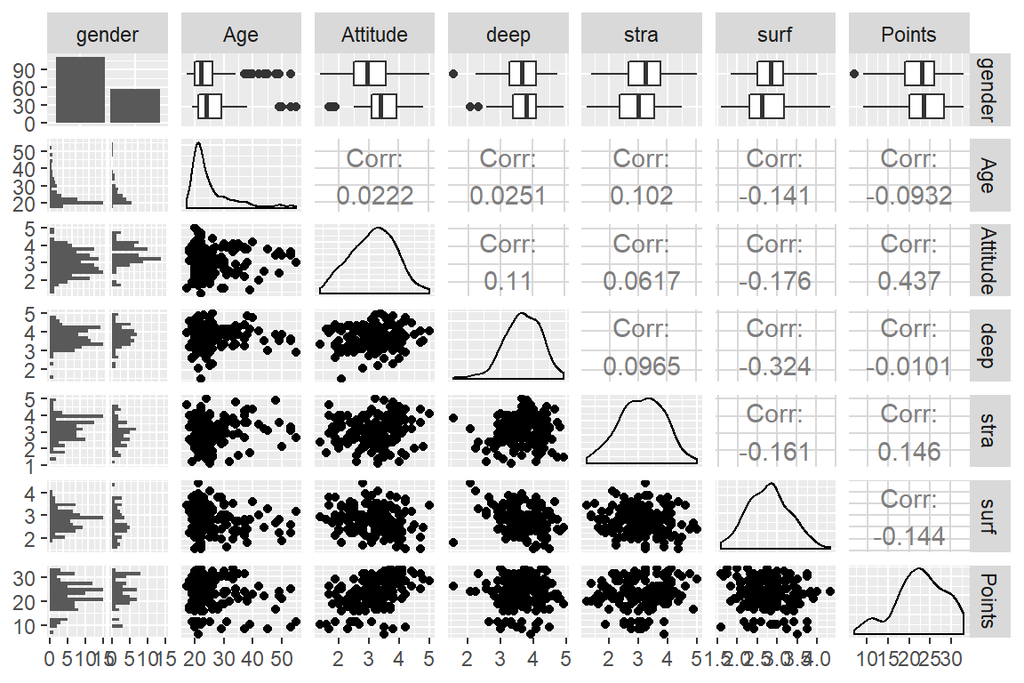

```r
ggpairs(harjoitusdata, lower = list(combo = wrap("facethist", bins = 20)))
```

"From the correlation picture we can see that the strongest correlations is between the global attitude towards statistics and total points. This correleation is positive. Lowest correlation is between deep learning and total Points.

## 3 & 4 Regression model

```r
m1 <- lm(Points ~ Attitude + stra + Age, data = harjoitusdata)

summary(m1)
```

```
##
## Call:
## lm(formula = Points ~ Attitude + stra + Age, data = harjoitusdata)
##
## Residuals:
##      Min       1Q   Median       3Q      Max
## -18.1149  -3.2003   0.3303   3.4129  10.7599
##
## Coefficients:
##             Estimate Std. Error t value Pr(>|t|)
## (Intercept) 10.89543    2.64834   4.114 6.17e-05 ***
## Attitude     3.48077    0.56220   6.191 4.72e-09 ***
## stra         1.00371    0.53434   1.878   0.0621 .
## Age         -0.08822    0.05302  -1.664   0.0981 .
## ---
## Signif. codes:  0 '***' 0.001 '**' 0.01 '*' 0.05 '.' 0.1 ' ' 1
##
## Residual standard error: 5.26 on 162 degrees of freedom
## Multiple R-squared:  0.2182, Adjusted R-squared:  0.2037
## F-statistic: 15.07 on 3 and 162 DF,  p-value: 1.07e-08
```

```r
m2 <- lm(Points ~ Attitude + deep + surf, data = harjoitusdata)

summary(m2)
```

```
##
## Call:
## lm(formula = Points ~ Attitude + deep + surf, data = harjoitusdata)
##
## Residuals:
##      Min       1Q   Median       3Q      Max
## -16.9168  -3.1487   0.3667   3.8326  11.3519
##
## Coefficients:
##             Estimate Std. Error t value Pr(>|t|)
## (Intercept)  18.3551     4.7124   3.895 0.000143 ***
## Attitude      3.4661     0.5766   6.011 1.18e-08 ***
## deep         -0.9485     0.7903  -1.200 0.231815
## surf         -1.0911     0.8360  -1.305 0.193669
## ---
## Signif. codes:  0 '***' 0.001 '**' 0.01 '*' 0.05 '.' 0.1 ' ' 1
##
## Residual standard error: 5.313 on 162 degrees of freedom
## Multiple R-squared:  0.2024, Adjusted R-squared:  0.1876
## F-statistic:  13.7 on 3 and 162 DF,  p-value: 5.217e-08
```

```r
m3 <- lm(Points ~ Attitude, data = harjoitusdata)

summary(m3)
```

```
##
## Call:
## lm(formula = Points ~ Attitude, data = harjoitusdata)
##
## Residuals:
##      Min       1Q   Median       3Q      Max
## -16.9763  -3.2119   0.4339   4.1534  10.6645
##
## Coefficients:
##             Estimate Std. Error t value Pr(>|t|)
## (Intercept)  11.6372     1.8303   6.358 1.95e-09 ***
## Attitude      3.5255     0.5674   6.214 4.12e-09 ***
## ---
## Signif. codes:  0 '***' 0.001 '**' 0.01 '*' 0.05 '.' 0.1 ' ' 1
##
## Residual standard error: 5.32 on 164 degrees of freedom
## Multiple R-squared:  0.1906, Adjusted R-squared:  0.1856
## F-statistic: 38.61 on 1 and 164 DF,  p-value: 4.119e-09
```

From the summary table it can be seen that 1 higher point in attitude rises the points total (B) by 3,46.

The multiple squared for the model 1 was 0,2182 and for model 2 it was 0,2024. This describes how much these variables explain the variation of the dependent. It means that 80 % of the variation is explained by other factors

In model 3 i only have the attitude as the explanatory variable. This model has the r square of 19,06 %"